# Sulawesi Selatan dalam Angka Visual

### 5.0.21 Takalar

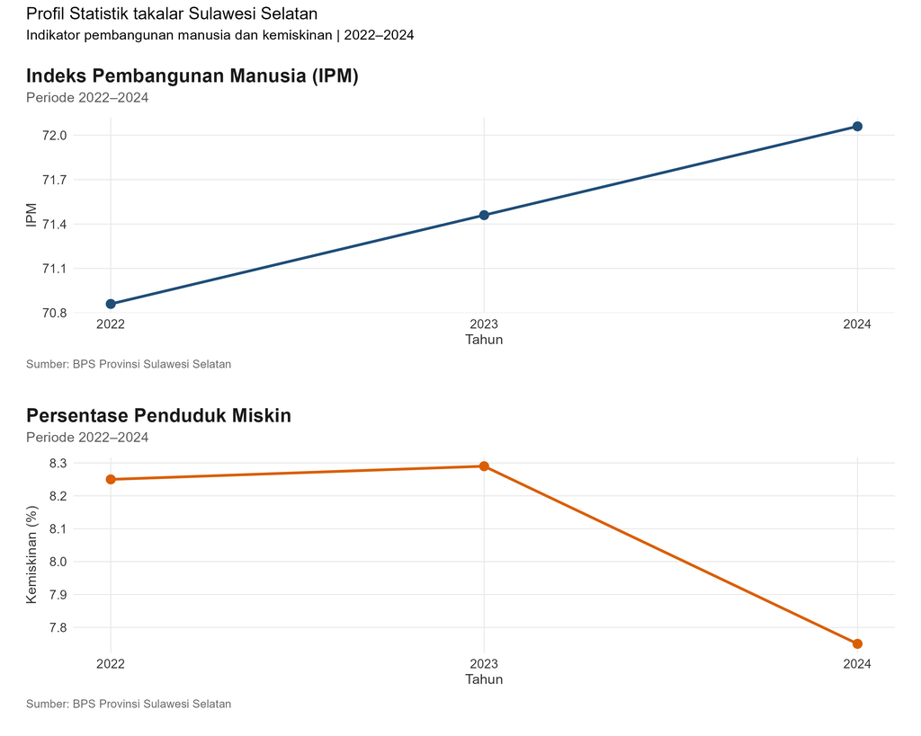

### 5.0.22 Tana Toraja

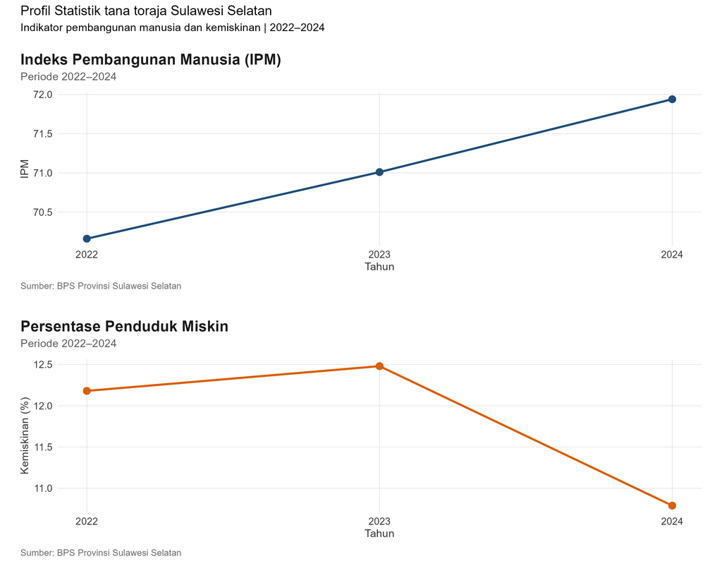

### 5.0.23 Toraja Utara

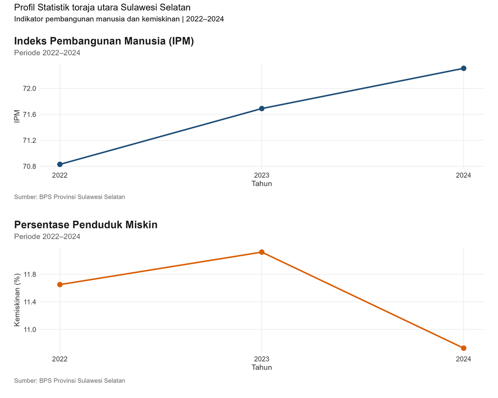

### 5.0.24 Wajo

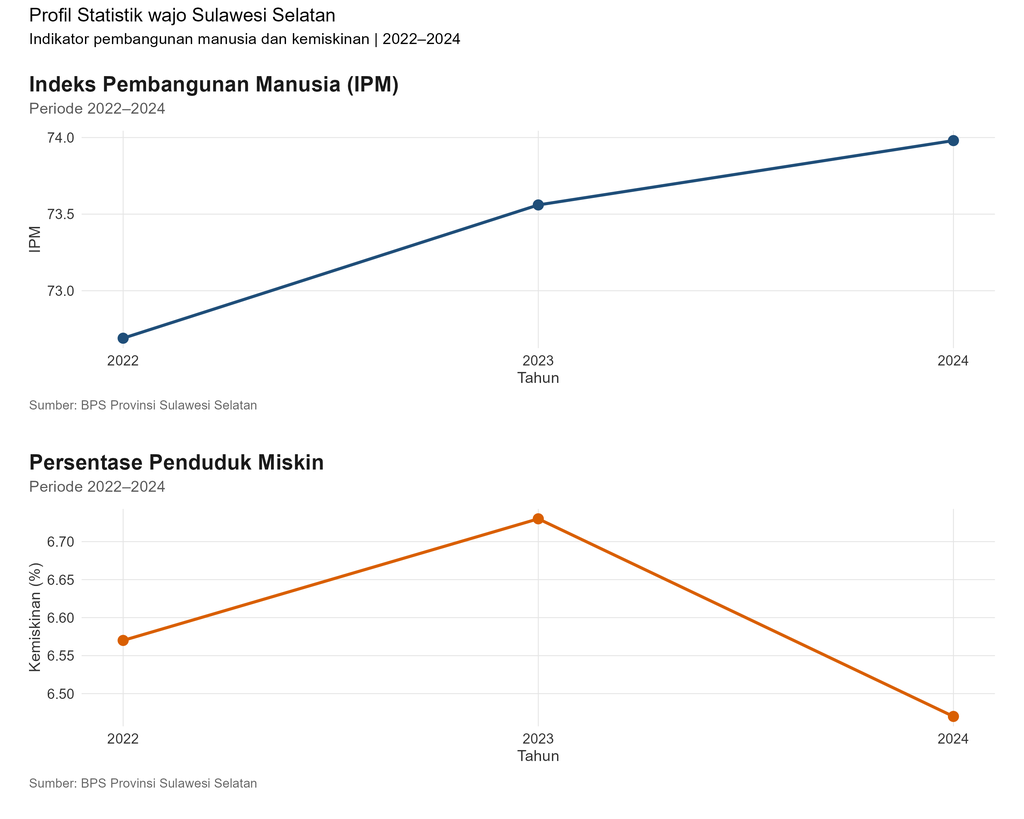

# 6 Ketidakpastian: Interval Bootstrap

Interval bootstrap `95%` menggunakan **`B = 1.999` replikasi** replikasi untuk merangkum variasi estimasi rata-rata indikator berdasarkan pengambilan ulang sampel.

### 6.0.1 IPM

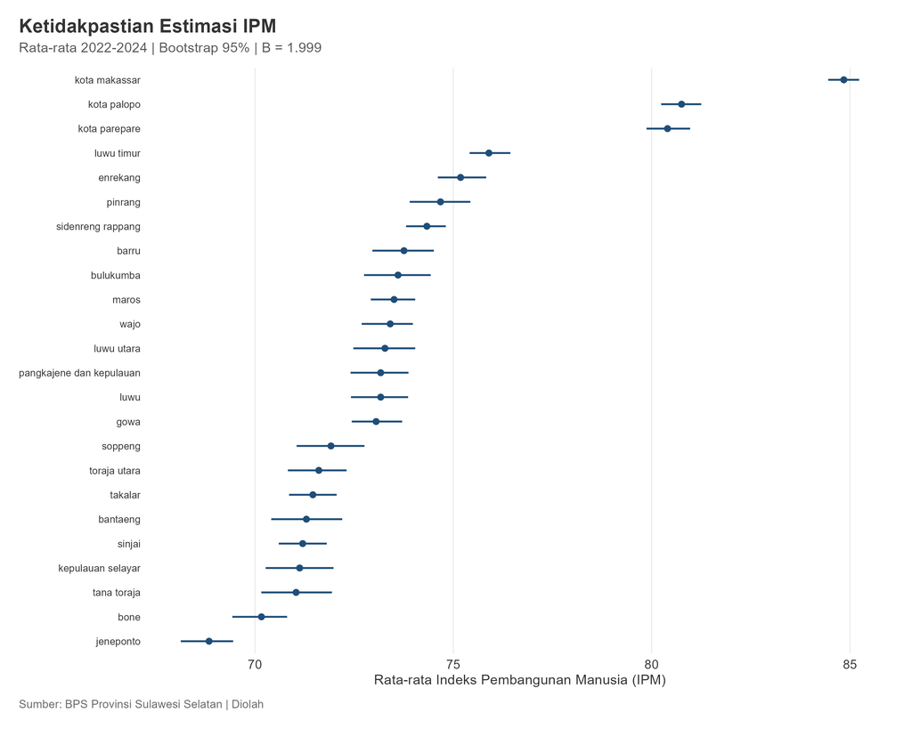

### 6.0.2 Penduduk Miskin

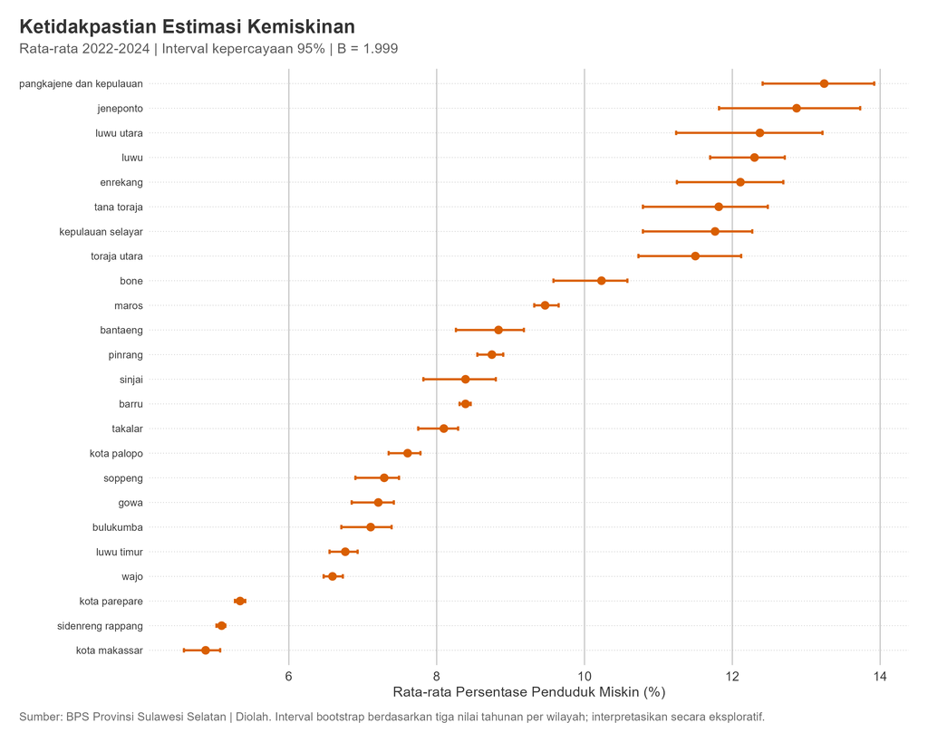

Grafik autoplot() menggunakan metode S3 untuk menampilkan estimasi titik dan error bar, dengan interval yang lebih lebar menunjukkan variasi estimasi yang lebih besar dalam prosedur bootstrap.

# 7 Inferensi Visual: Lineup

Lineup berisi `20` panel: satu panel data asli dan `19` panel hasil permutasi/null. Pengamat diminta memilih panel yang tampak paling berbeda. Pendekatan ini mengevaluasi apakah pola data asli cukup menonjol dibandingkan pola yang mungkin muncul secara acak.

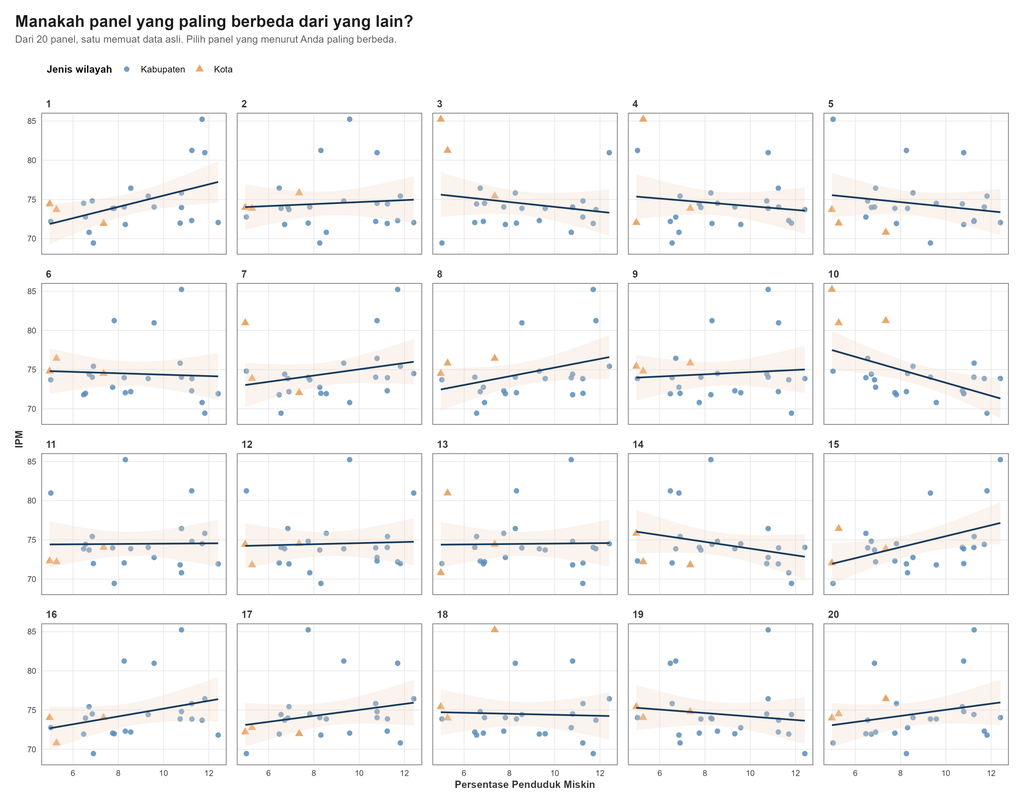

Berdasarkan ringkasan analisis yang tersimpan, **`6` dari `10` pengamat** memilih panel asli. Dengan peluang tebak acak `1/20`, nilai p visual yang tercatat sekitar **`2,75 × 10⁻⁶`**. Hasil ini mendukung bahwa pola pada panel asli cukup mudah dibedakan dalam lineup tersebut, tetapi kesimpulan tetap bergantung pada desain lineup dan jumlah pengamat.

Berkas jawaban dan ringkasan analisis disimpan di `data/jawaban_lineup.csv` dan `keluaran/analisis_lineup/`. Berkas kunci panel asli disimpan terpisah di `keluaran/kunci_lineup/kunci.rds` agar tidak tercampur dengan jawaban pengamat.

# 8 Fungsi dan Reproduksibilitas

Analisis disusun dalam skrip terpisah agar proses pembersihan data, persiapan peta, makeover, tema, galeri, profil, lineup, bootstrap, dan `autoplot()` dapat ditelusuri. Skrip utama berada di folder `R/`.

Urutan kerja yang disarankan dari direktori utama proyek:

1. Jalankan `R/01_membersihkan_data.R` untuk membangun data bersih.
2. Jalankan `R/02_menyiapkan_peta.R` untuk menyiapkan keluaran spasial.
3. Jalankan skrip tema dan galeri sesuai kebutuhan (`R/04_theme_palet_tim.R`, `R/05_galeri.R`).
4. Jalankan `R/06_fungsi grafik dan Lineup.R` dan `R/08_analisis lineup.R` untuk fungsi serta analisis lineup.
5. Jalankan `R/09_bootstrap.R` sebelum `R/10_autoplot.R` untuk memperbarui hasil ketidakpastian.
6. Render `atlas.qmd` menggunakan Quarto dari direktori utama proyek.

Data bersih mencakup `72` baris dan `24` wilayah untuk tiga tahun. Sebelum menjalankan ulang, pastikan paket yang dipakai telah terpasang dan seluruh skrip dijalankan dari direktori proyek agar path relatif tetap sesuai.

# 9 Keterbatasan

- Periode tiga tahun memberi gambaran awal, tetapi belum cukup untuk menyimpulkan tren jangka panjang.
- Korelasi dan garis regresi pada grafik hubungan bersifat deskriptif; keduanya tidak membuktikan pengaruh kausal.
- Estimasi bootstrap merangkum ketidakpastian menurut prosedur pengambilan ulang yang digunakan, tetapi hasilnya tetap dipengaruhi struktur dan ukuran data.
- Lineup menggunakan `10` respons pengamat pada berkas yang tersedia. Penambahan pengamat dan dokumentasi prosedur pengamatan akan memperkuat evaluasi inferensi visual.
- Batas wilayah, definisi indikator, serta tahun rujukan perlu diperiksa kembali jika sumber data diperbarui.

# 10 Deklarasi Penggunaan AI

AI generatif digunakan sebagai alat bantu untuk penyuntingan bahasa, penataan struktur narasi, dan dukungan teknis dalam penyusunan dokumen. Pemilihan indikator, pemeriksaan data, keputusan analisis, verifikasi keluaran, dan tanggung jawab atas isi akhir tetap berada pada anggota Tim 1. Seluruh angka dan visual perlu dicocokkan dengan berkas sumber sebelum pengumpulan.

# 11 Sumber Data

- **Badan Pusat Statistik Provinsi Sulawesi Selatan** — data Indeks Pembangunan Manusia dan persentase penduduk miskin, `2022–2024`.
- **geoBoundaries** — batas administratif ADM2 yang disederhanakan untuk visualisasi. Keterangan penggunaan terdapat pada `data/data-batas-peta/CITATION-AND-USE-geoBoundaries.txt`.

## 11.1 Repositori GitHub

Skrip R, struktur proyek, dan berkas pendukung pengembangan Atlas Visual Sulawesi Selatan dapat diakses melalui repositori GitHub Tim 1.

**Repositori GitHub Tim 1:** [Atlas Visual Sulawesi Selatan](https://github.com/nathaniaoktaviag26h-oss/Atlas-Visual-Sulsel)

Atlas Visual Sulawesi Selatan · Tim 1 · Komputasi Statistika Lanjut · 2026